# Framingham Study Plots

Jonatas Amorim

2024-05-15

# Introduction

This is a Capstone Project for the Google Data Analytics Professional Certification.

# Framingham Study Plots

The Framingham Heart Study is a long term prospective study of the etiology of cardiovascular disease among a population of free living subjects in the community of Framingham, Massachusetts. The Framingham Heart Study was a landmark study in epidemiology in that it was the first prospective study of cardiovascular disease and identified the concept of risk factors and their joint effects. The study began in 1948 and 5,209 subjects were initially enrolled in the study.

In this analysis there will some plots about this study and considerations about health behaviors based on this dataset.

## Ask

### Scenario

Cardiovascular diseases are a major burden for the Global Healthcare market and the Framingham Heart Study build a dataset with variables related to this disease.

### Main Analysis Task

What is the relationship between the BMI (Body Mass Index) variable and the heart diseases?

#### Install and load libraries

To proceed the data analysis the following libraries will be needed:

```r
#install.packages("tidyverse")
#install.packages("ggplot2")
#install.packages("reshape2")
#install.packages("psych")
#install.packages("skimr")
library(dplyr)
library(ggplot2)
library(reshape2)
library(psych)
library(skimr)
```

## Prepare

### About the Framingham Heart Study dataset

The enclosed dataset is a subset of the data collected as part of the Framingham study and includes laboratory, clinic, questionnaire, and adjudicated event data on 4,434 participants. Participant clinic data was collected during three examination periods, approximately 6 years apart, from roughly 1956 to 1968. Each participant was followed for a total of 24 years for the outcome of the following events: Angina Pectoris, Myocardial Infarction, Atherothrombotic Infarction or Cerebral Hemorrhage (Stroke) or death. (NOTE: Although the enclosed dataset contains Framingham data ‘as collected’ by Framingham investigators, specific methods were employed to ensure an anonymous dataset that protects patient confidentiality; therefore, this dataset is inappropriate for publication purposes).

Evaluation of ROCCC

- Reliable - Data is reliable and it was collected using the best practices in the time of collection.
- Original - The data is original and was produced in the community of Framingham, Massachusetts.
- Comprehensive - The data is comprehensive with many important variables
- Current - Participant clinic data was collected during three examination periods, approximately 6 years apart, from roughly 1956 to 1968. Each participant was followed for a total of 24 years.
- Cited – The data is very important and has been cited and used many times by various analysts.

```r
fhs_data <- read.csv("/home/jonatas/Dev/R/bdah/frmgham2.csv")
```

```r
head(fhs_data)
```

```
##   RANDID SEX TOTCHOL AGE SYSBP DIABP CURSMOKE CIGPDAY   BMI DIABETES BPMEDS
## 1   2448   1     195  39 106.0  70.0        0       0 26.97        0      0
## 2   2448   1     209  52 121.0  66.0        0       0    NA        0      0
## 3   6238   2     250  46 121.0  81.0        0       0 28.73        0      0
## 4   6238   2     260  52 105.0  69.5        0       0 29.43        0      0
## 5   6238   2     237  58 108.0  66.0        0       0 28.50        0      0
## 6   9428   1     245  48 127.5  80.0        1      20 25.34        0      0
##   HEARTRTE GLUCOSE educ PREVCHD PREVAP PREVMI PREVSTRK PREVHYP TIME PERIOD HDLC
## 1       80      77    4       0      0      0        0       0    0      1   NA
## 2       69      92    4       0      0      0        0       0 4628      3   31
## 3       95      76    2       0      0      0        0       0    0      1   NA
## 4       80      86    2       0      0      0        0       0 2156      2   NA
## 5       80      71    2       0      0      0        0       0 4344      3   54
## 6       75      70    1       0      0      0        0       0    0      1   NA
##   LDLC DEATH ANGINA HOSPMI MI_FCHD ANYCHD STROKE CVD HYPERTEN TIMEAP TIMEMI
## 1   NA     0      0      1       1      1      0   1        0   8766   6438
## 2  178     0      0      1       1      1      0   1        0   8766   6438
## 3   NA     0      0      0       0      0      0   0        0   8766   8766
## 4   NA     0      0      0       0      0      0   0        0   8766   8766
## 5  141     0      0      0       0      0      0   0        0   8766   8766
## 6   NA     0      0      0       0      0      0   0        0   8766   8766
##   TIMEMIFC TIMECHD TIMESTRK TIMECVD TIMEDTH TIMEHYP
## 1     6438    6438     8766    6438    8766    8766
## 2     6438    6438     8766    6438    8766    8766
## 3     8766    8766     8766    8766    8766    8766
## 4     8766    8766     8766    8766    8766    8766
## 5     8766    8766     8766    8766    8766    8766
## 6     8766    8766     8766    8766    8766    8766
```

```r
str(fhs_data)
```

```
## 'data.frame':    11627 obs. of  39 variables:
##  $ RANDID  : int  2448 2448 6238 6238 6238 9428 9428 10552 10552 11252 ...
##  $ SEX     : int  1 1 2 2 2 1 1 2 2 2 ...
##  $ TOTCHOL : int  195 209 250 260 237 245 283 225 232 285 ...
##  $ AGE     : int  39 52 46 52 58 48 54 61 67 46 ...
##  $ SYSBP   : num  106 121 121 105 108 ...
##  $ DIABP   : num  70 66 81 69.5 66 80 89 95 109 84 ...
##  $ CURSMOKE: int  0 0 0 0 0 1 1 1 1 1 ...
##  $ CIGPDAY : int  0 0 0 0 0 20 30 30 20 23 ...
##  $ BMI     : num  27 NA 28.7 29.4 28.5 ...
##  $ DIABETES: int  0 0 0 0 0 0 0 0 0 0 ...
##  $ BPMEDS  : int  0 0 0 0 0 0 0 0 0 0 ...
##  $ HEARTRTE: int  80 69 95 80 80 75 75 65 60 85 ...
##  $ GLUCOSE : int  77 92 76 86 71 70 87 103 89 85 ...
##  $ educ    : int  4 4 2 2 2 1 1 3 3 3 ...
```

[output cut: 25 more lines]

## Process

### Methods and tools

To process the dataset the R programming language will be used. This is a powerful tool with many capabilities and packages used to manipulate data. In only one Integrated Development Environment (IDE), it is possible to clean, analyze and visualize the data, asserting it’s integrity.

Change all the column names to upper case.

```r
colnames(fhs_data) <- toupper(colnames(fhs_data))
```

Check all the column names and data.

```r
glimpse(fhs_data)
```

```
## Rows: 11,627
## Columns: 39
## $ RANDID   <int> 2448, 2448, 6238, 6238, 6238, 9428, 9428, 10552, 10552, 11252…
## $ SEX      <int> 1, 1, 2, 2, 2, 1, 1, 2, 2, 2, 2, 2, 2, 2, 2, 2, 2, 2, 2, 2, 1…
## $ TOTCHOL  <int> 195, 209, 250, 260, 237, 245, 283, 225, 232, 285, 343, NA, 22…
## $ AGE      <int> 39, 52, 46, 52, 58, 48, 54, 61, 67, 46, 51, 58, 43, 49, 55, 6…
## $ SYSBP    <dbl> 106.0, 121.0, 121.0, 105.0, 108.0, 127.5, 141.0, 150.0, 183.0…
## $ DIABP    <dbl> 70.0, 66.0, 81.0, 69.5, 66.0, 80.0, 89.0, 95.0, 109.0, 84.0, …
## $ CURSMOKE <int> 0, 0, 0, 0, 0, 1, 1, 1, 1, 1, 1, 1, 0, 0, 0, 0, 0, 1, 1, 1, 0…
## $ CIGPDAY  <int> 0, 0, 0, 0, 0, 20, 30, 30, 20, 23, 30, 30, 0, 0, 0, 0, 0, 20,…
## $ BMI      <dbl> 26.97, NA, 28.73, 29.43, 28.50, 25.34, 25.34, 28.58, 30.18, 2…
## $ DIABETES <int> 0, 0, 0, 0, 0, 0, 0, 0, 0, 0, 0, 0, 0, 0, 1, 0, 0, 0, 0, 0, 0…
## $ BPMEDS   <int> 0, 0, 0, 0, 0, 0, 0, 0, 0, 0, 0, 0, 0, 1, 1, 0, 0, 0, 0, 0, 0…
## $ HEARTRTE <int> 80, 69, 95, 80, 80, 75, 75, 65, 60, 85, 90, 74, 77, 120, 86, …
## $ GLUCOSE  <int> 77, 92, 76, 86, 71, 70, 87, 103, 89, 85, 72, NA, 99, 86, 81, …
```

[output cut: 26 more lines]

Remove duplicates in the dataset.

```r
fhs_data <- distinct(fhs_data)
```

Check the statistics of the dataset.

```r
summary(fhs_data)
```

```
##      RANDID             SEX           TOTCHOL           AGE
##  Min.   :   2448   Min.   :1.000   Min.   :107.0   Min.   :32.00
##  1st Qu.:2474378   1st Qu.:1.000   1st Qu.:210.0   1st Qu.:48.00
##  Median :5006008   Median :2.000   Median :238.0   Median :54.00
##  Mean   :5004741   Mean   :1.568   Mean   :241.2   Mean   :54.79
##  3rd Qu.:7472730   3rd Qu.:2.000   3rd Qu.:268.0   3rd Qu.:62.00
##  Max.   :9999312   Max.   :2.000   Max.   :696.0   Max.   :81.00
##                                    NA's   :409
##      SYSBP           DIABP           CURSMOKE         CIGPDAY
##  Min.   : 83.5   Min.   : 30.00   Min.   :0.0000   Min.   : 0.00
##  1st Qu.:120.0   1st Qu.: 75.00   1st Qu.:0.0000   1st Qu.: 0.00
##  Median :132.0   Median : 82.00   Median :0.0000   Median : 0.00
##  Mean   :136.3   Mean   : 83.04   Mean   :0.4325   Mean   : 8.25
##  3rd Qu.:149.0   3rd Qu.: 90.00   3rd Qu.:1.0000   3rd Qu.:20.00
##  Max.   :295.0   Max.   :150.00   Max.   :1.0000   Max.   :90.00
##                                                    NA's   :79
##       BMI           DIABETES           BPMEDS          HEARTRTE
##  Min.   :14.43   Min.   :0.00000   Min.   :0.0000   Min.   : 37.00
##  1st Qu.:23.09   1st Qu.:0.00000   1st Qu.:0.0000   1st Qu.: 69.00
##  Median :25.48   Median :0.00000   Median :0.0000   Median : 75.00
##  Mean   :25.88   Mean   :0.04558   Mean   :0.0856   Mean   : 76.78
##  3rd Qu.:28.07   3rd Qu.:0.00000   3rd Qu.:0.0000   3rd Qu.: 85.00
##  Max.   :56.80   Max.   :1.00000   Max.   :1.0000   Max.   :220.00
##  NA's   :52                        NA's   :593      NA's   :6
##     GLUCOSE            EDUC         PREVCHD            PREVAP
##  Min.   : 39.00   Min.   :1.00   Min.   :0.00000   Min.   :0.00000
##  1st Qu.: 72.00   1st Qu.:1.00   1st Qu.:0.00000   1st Qu.:0.00000
##  Median : 80.00   Median :2.00   Median :0.00000   Median :0.00000
##  Mean   : 84.12   Mean   :1.99   Mean   :0.07242   Mean   :0.05393
##  3rd Qu.: 89.00   3rd Qu.:3.00   3rd Qu.:0.00000   3rd Qu.:0.00000
##  Max.   :478.00   Max.   :4.00   Max.   :1.00000   Max.   :1.00000
##  NA's   :1440     NA's   :295
##      PREVMI           PREVSTRK          PREVHYP            TIME
##  Min.   :0.00000   Min.   :0.00000   Min.   :0.0000   Min.   :   0
##  1st Qu.:0.00000   1st Qu.:0.00000   1st Qu.:0.0000   1st Qu.:   0
##  Median :0.00000   Median :0.00000   Median :0.0000   Median :2156
##  Mean   :0.03217   Mean   :0.01307   Mean   :0.4596   Mean   :1957
##  3rd Qu.:0.00000   3rd Qu.:0.00000   3rd Qu.:1.0000   3rd Qu.:4252
##  Max.   :1.00000   Max.   :1.00000   Max.   :1.0000   Max.   :4854
##
```

[output cut: 25 more lines]

```
##  Min.   :   0   Min.   :   0   Min.   :   0   Min.   :   0   Min.   :   0
##  1st Qu.:7212   1st Qu.:7050   1st Qu.:5598   1st Qu.:7295   1st Qu.:6004
##  Median :8766   Median :8766   Median :8766   Median :8766   Median :8766
##  Mean   :7594   Mean   :7543   Mean   :7008   Mean   :7661   Mean   :7166
##  3rd Qu.:8766   3rd Qu.:8766   3rd Qu.:8766   3rd Qu.:8766   3rd Qu.:8766
##  Max.   :8766   Max.   :8766   Max.   :8766   Max.   :8766   Max.   :8766
##
##     TIMEDTH        TIMEHYP
##  Min.   :  26   Min.   :   0
##  1st Qu.:7798   1st Qu.:   0
##  Median :8766   Median :2429
##  Mean   :7854   Mean   :3599
##  3rd Qu.:8766   3rd Qu.:7329
##  Max.   :8766   Max.   :8766
##
```

## Analyze

### Overview of the Framingham Heart Study dataset

```r
skim_without_charts(fhs_data)
```

Data summary

| Name | fhs_data |
| --- | --- |
| Number of rows | 11627 |
| Number of columns | 39 |
| _______________________ |  |
| Column type frequency: |  |
| numeric | 39 |
| ________________________ |  |
| Group variables | None |

**Variable type: numeric**

| skim_variable | n_missing | complete_rate | mean | sd | p0 | p25 | p50 | p75 | p100 |
| --- | --- | --- | --- | --- | --- | --- | --- | --- | --- |
| RANDID | 0 | 1.00 | 5004740.92 | 2900877.44 | 2448.00 | 2474378.00 | 5006008.00 | 7472730.00 | 9999312.0 |
| SEX | 0 | 1.00 | 1.57 | 0.50 | 1.00 | 1.00 | 2.00 | 2.00 | 2.0 |
| TOTCHOL | 409 | 0.96 | 241.16 | 45.37 | 107.00 | 210.00 | 238.00 | 268.00 | 696.0 |
| AGE | 0 | 1.00 | 54.79 | 9.56 | 32.00 | 48.00 | 54.00 | 62.00 | 81.0 |
| SYSBP | 0 | 1.00 | 136.32 | 22.80 | 83.50 | 120.00 | 132.00 | 149.00 | 295.0 |
| DIABP | 0 | 1.00 | 83.04 | 11.66 | 30.00 | 75.00 | 82.00 | 90.00 | 150.0 |
| CURSMOKE | 0 | 1.00 | 0.43 | 0.50 | 0.00 | 0.00 | 0.00 | 1.00 | 1.0 |
| CIGPDAY | 79 | 0.99 | 8.25 | 12.19 | 0.00 | 0.00 | 0.00 | 20.00 | 90.0 |
| BMI | 52 | 1.00 | 25.88 | 4.10 | 14.43 | 23.09 | 25.48 | 28.07 | 56.8 |
| DIABETES | 0 | 1.00 | 0.05 | 0.21 | 0.00 | 0.00 | 0.00 | 0.00 | 1.0 |
| BPMEDS | 593 | 0.95 | 0.09 | 0.28 | 0.00 | 0.00 | 0.00 | 0.00 | 1.0 |
| HEARTRTE | 6 | 1.00 | 76.78 | 12.46 | 37.00 | 69.00 | 75.00 | 85.00 | 220.0 |
| GLUCOSE | 1440 | 0.88 | 84.12 | 24.99 | 39.00 | 72.00 | 80.00 | 89.00 | 478.0 |
| EDUC | 295 | 0.97 | 1.99 | 1.03 | 1.00 | 1.00 | 2.00 | 3.00 | 4.0 |
| PREVCHD | 0 | 1.00 | 0.07 | 0.26 | 0.00 | 0.00 | 0.00 | 0.00 | 1.0 |
| PREVAP | 0 | 1.00 | 0.05 | 0.23 | 0.00 | 0.00 | 0.00 | 0.00 | 1.0 |
| PREVMI | 0 | 1.00 | 0.03 | 0.18 | 0.00 | 0.00 | 0.00 | 0.00 | 1.0 |
| PREVSTRK | 0 | 1.00 | 0.01 | 0.11 | 0.00 | 0.00 | 0.00 | 0.00 | 1.0 |
| PREVHYP | 0 | 1.00 | 0.46 | 0.50 | 0.00 | 0.00 | 0.00 | 1.00 | 1.0 |
| TIME | 0 | 1.00 | 1957.02 | 1758.78 | 0.00 | 0.00 | 2156.00 | 4252.50 | 4854.0 |
| PERIOD | 0 | 1.00 | 1.90 | 0.81 | 1.00 | 1.00 | 2.00 | 3.00 | 3.0 |
| HDLC | 8600 | 0.26 | 49.36 | 15.63 | 10.00 | 39.00 | 48.00 | 58.00 | 189.0 |
| LDLC | 8601 | 0.26 | 176.47 | 46.86 | 20.00 | 145.00 | 173.00 | 205.00 | 565.0 |
| DEATH | 0 | 1.00 | 0.30 | 0.46 | 0.00 | 0.00 | 0.00 | 1.00 | 1.0 |
| ANGINA | 0 | 1.00 | 0.16 | 0.37 | 0.00 | 0.00 | 0.00 | 0.00 | 1.0 |
| HOSPMI | 0 | 1.00 | 0.10 | 0.30 | 0.00 | 0.00 | 0.00 | 0.00 | 1.0 |
| MI_FCHD | 0 | 1.00 | 0.15 | 0.36 | 0.00 | 0.00 | 0.00 | 0.00 | 1.0 |
| ANYCHD | 0 | 1.00 | 0.27 | 0.44 | 0.00 | 0.00 | 0.00 | 1.00 | 1.0 |
| STROKE | 0 | 1.00 | 0.09 | 0.29 | 0.00 | 0.00 | 0.00 | 0.00 | 1.0 |
| CVD | 0 | 1.00 | 0.25 | 0.43 | 0.00 | 0.00 | 0.00 | 0.00 | 1.0 |
| HYPERTEN | 0 | 1.00 | 0.74 | 0.44 | 0.00 | 0.00 | 1.00 | 1.00 | 1.0 |
| TIMEAP | 0 | 1.00 | 7241.56 | 2477.78 | 0.00 | 6224.00 | 8766.00 | 8766.00 | 8766.0 |
| TIMEMI | 0 | 1.00 | 7593.85 | 2136.73 | 0.00 | 7212.00 | 8766.00 | 8766.00 | 8766.0 |
| TIMEMIFC | 0 | 1.00 | 7543.04 | 2192.12 | 0.00 | 7049.50 | 8766.00 | 8766.00 | 8766.0 |
| TIMECHD | 0 | 1.00 | 7008.15 | 2641.34 | 0.00 | 5598.50 | 8766.00 | 8766.00 | 8766.0 |
| TIMESTRK | 0 | 1.00 | 7660.88 | 2011.08 | 0.00 | 7295.00 | 8766.00 | 8766.00 | 8766.0 |
| TIMECVD | 0 | 1.00 | 7166.08 | 2541.67 | 0.00 | 6004.00 | 8766.00 | 8766.00 | 8766.0 |
| TIMEDTH | 0 | 1.00 | 7854.10 | 1788.37 | 26.00 | 7797.50 | 8766.00 | 8766.00 | 8766.0 |
| TIMEHYP | 0 | 1.00 | 3598.96 | 3464.16 | 0.00 | 0.00 | 2429.00 | 7329.00 | 8766.0 |

### Heart Rate observations

Check the statistics related to the variable HEARTRTE.

```r
with(fhs_data, summary(HEARTRTE))
```

```
##    Min. 1st Qu.  Median    Mean 3rd Qu.    Max.    NA's
##   37.00   69.00   75.00   76.78   85.00  220.00       6
```

```r
with(fhs_data, describe(HEARTRTE))
```

```
##    vars     n  mean    sd median trimmed   mad min max range skew kurtosis   se
## X1    1 11621 76.78 12.46     75   76.15 10.38  37 220   183 0.68     2.08 0.12
```

Plot showing the heart rate of the study population.

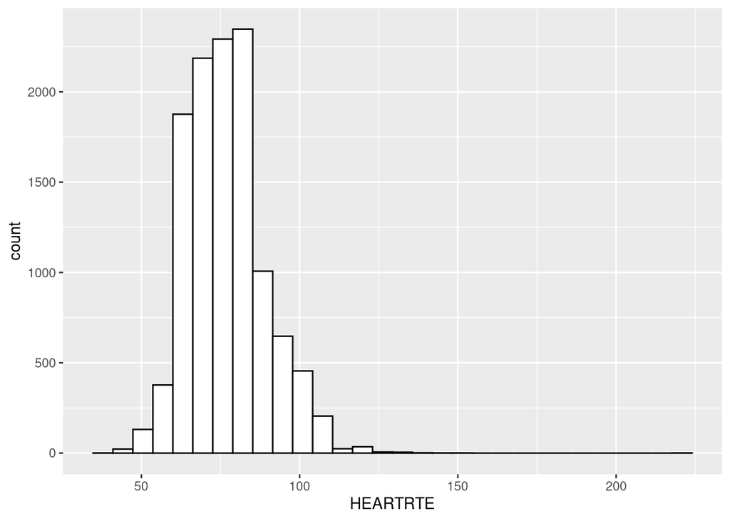

```r
ggplot(fhs_data, aes(HEARTRTE)) +
  geom_histogram(color = "black", fill = "white")
```

Plot showing the heart rate of the study population using the facet_wrap() function to create a separate plot for each SEX (1=Men 2=Women) segment:

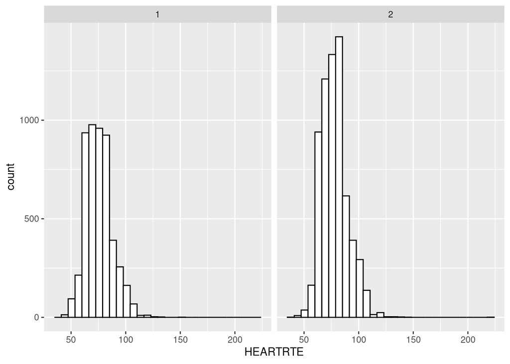

```r
ggplot(fhs_data, aes(HEARTRTE)) +
  geom_histogram(color = "black", fill = "white") +
  facet_wrap(~SEX)
```

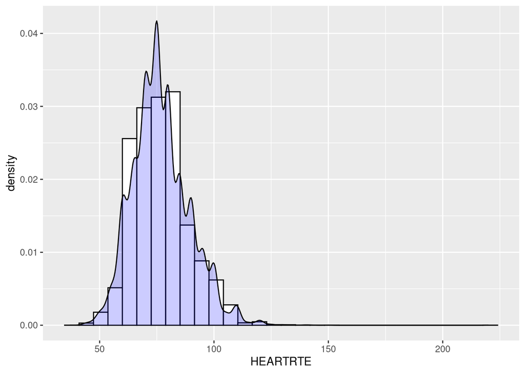

```r
ggplot(fhs_data, aes(x = HEARTRTE, y = ..density..)) +
  geom_histogram(color = "black", fill = "white") +
  geom_density(fill = "blue", alpha = 0.2)
```

### BMI vs Education

The next plot insert the variable education in the analysis.

Attained Education: * 1=0-11 years * 2=High School Diploma, GED * 3=Some College, Vocational School * 4=College (BS, BA) degree or more

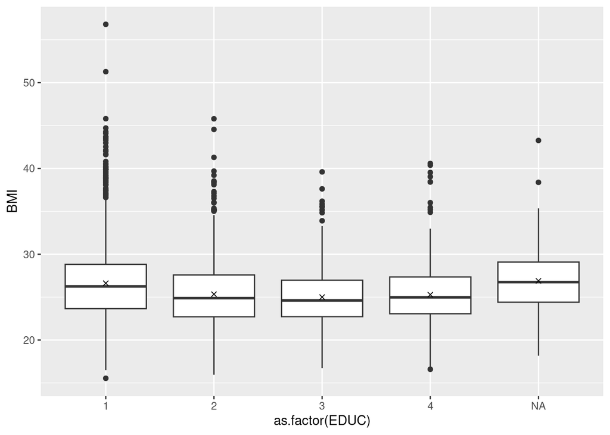

```r
ggplot(filter(fhs_data, PERIOD == 1), aes(x = as.factor(EDUC), y = BMI)) +
  geom_boxplot() +
  stat_summary(fun.y = "mean", geom = "point", shape = 4)
```

The variance analysis between BMI and Education is:

```r
summary(aov(BMI ~ as.factor(EDUC), data = filter(fhs_data, PERIOD == 1)))
```

```
##                   Df Sum Sq Mean Sq F value Pr(>F)
## as.factor(EDUC)    3   2064   688.1    42.1 <2e-16 ***
## Residuals       4299  70255    16.3
## ---
## Signif. codes:  0 '***' 0.001 '**' 0.01 '*' 0.05 '.' 0.1 ' ' 1
## 131 observations deleted due to missingness
```

### BMI vs Stroke

The next plots insert the variable stroke in the analysis.

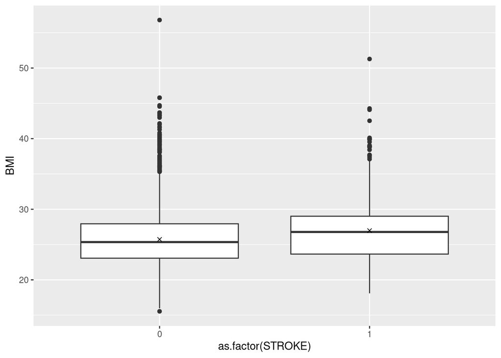

```r
ggplot(filter(fhs_data, PERIOD == 1), aes(x = as.factor(STROKE), y = BMI)) +
  geom_boxplot() +
  stat_summary(fun.y = "mean", geom = "point", shape = 4)
```

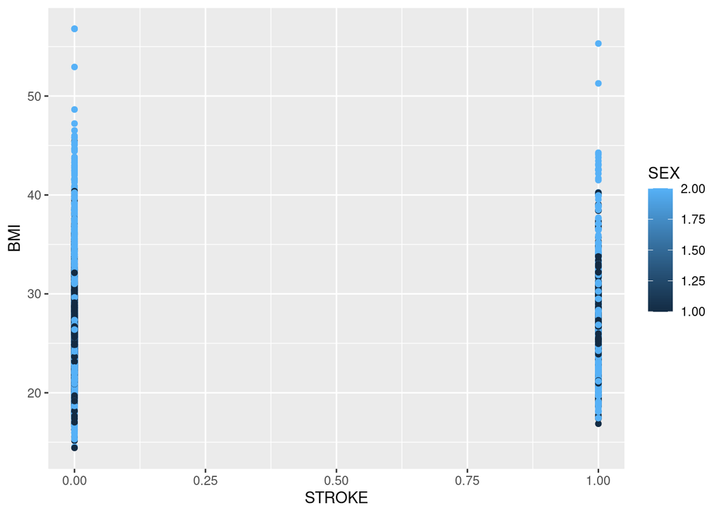

```r
ggplot(data=fhs_data, aes(x=STROKE, y=BMI))+
  geom_point(aes(colour = SEX))
```

And the variance analysis between BMI and STROKE is:

```r
summary(aov(BMI ~ as.factor(STROKE), data = filter(fhs_data, PERIOD == 1)))
```

```
##                     Df Sum Sq Mean Sq F value   Pr(>F)
## as.factor(STROKE)    1    579   578.6   34.65 4.23e-09 ***
## Residuals         4413  73687    16.7
## ---
## Signif. codes:  0 '***' 0.001 '**' 0.01 '*' 0.05 '.' 0.1 ' ' 1
## 19 observations deleted due to missingness
```

### BMI vs CVD

Now we can observe the relation between BMI and Cardiovascular Disease (CVD).

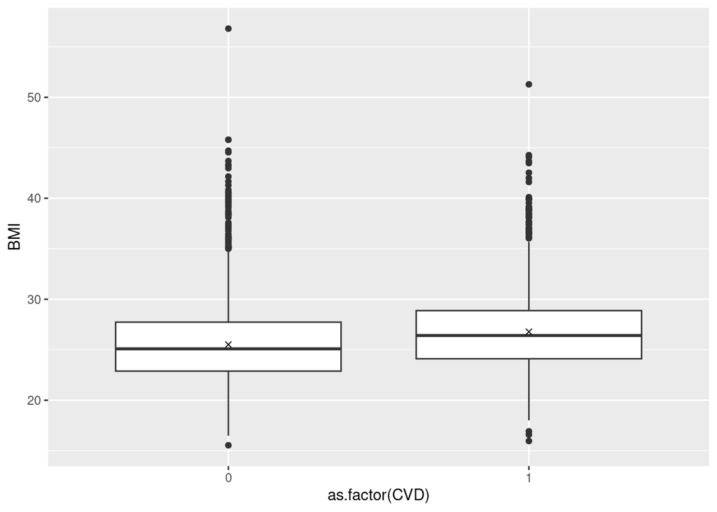

```r
ggplot(filter(fhs_data, PERIOD == 1), aes(x = as.factor(CVD), y = BMI)) +
  geom_boxplot() +
  stat_summary(fun.y = "mean", geom = "point", shape = 4)
```

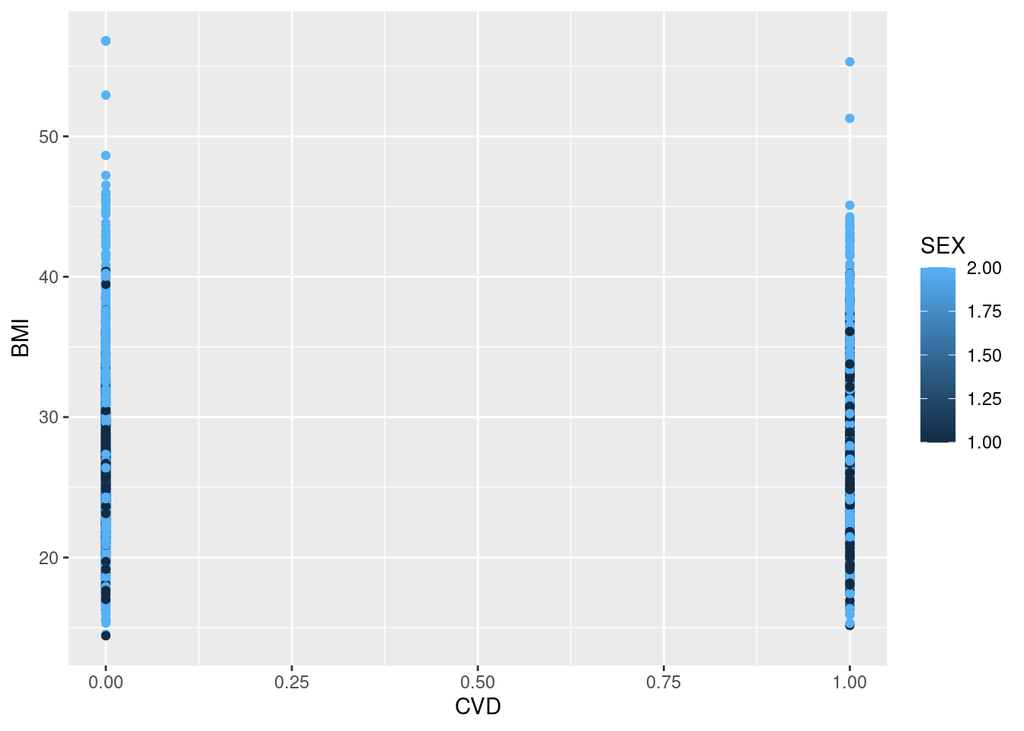

```r
ggplot(data=fhs_data, aes(x=CVD, y=BMI))+
  geom_point(aes(colour = SEX))
```

The variance analysis between BMI and CVD is:

```r
summary(aov(BMI ~ as.factor(CVD), data = filter(fhs_data, PERIOD == 1)))
```

```
##                  Df Sum Sq Mean Sq F value Pr(>F)
## as.factor(CVD)    1   1370  1369.7   82.92 <2e-16 ***
## Residuals      4413  72896    16.5
## ---
## Signif. codes:  0 '***' 0.001 '**' 0.01 '*' 0.05 '.' 0.1 ' ' 1
## 19 observations deleted due to missingness
```

### BMI vs Diabetes

Analyzing Diabetes versus BMI give us the following plots.

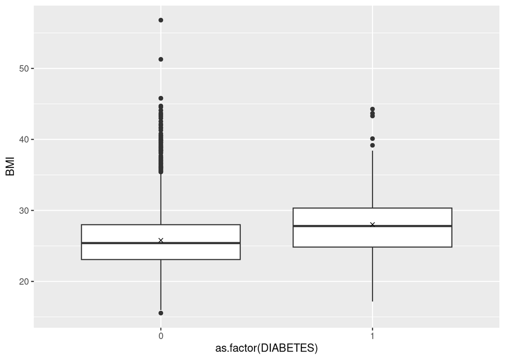

```r
ggplot(filter(fhs_data, PERIOD == 1), aes(x = as.factor(DIABETES), y = BMI)) +
  geom_boxplot() +
  stat_summary(fun.y = "mean", geom = "point", shape = 4)
```

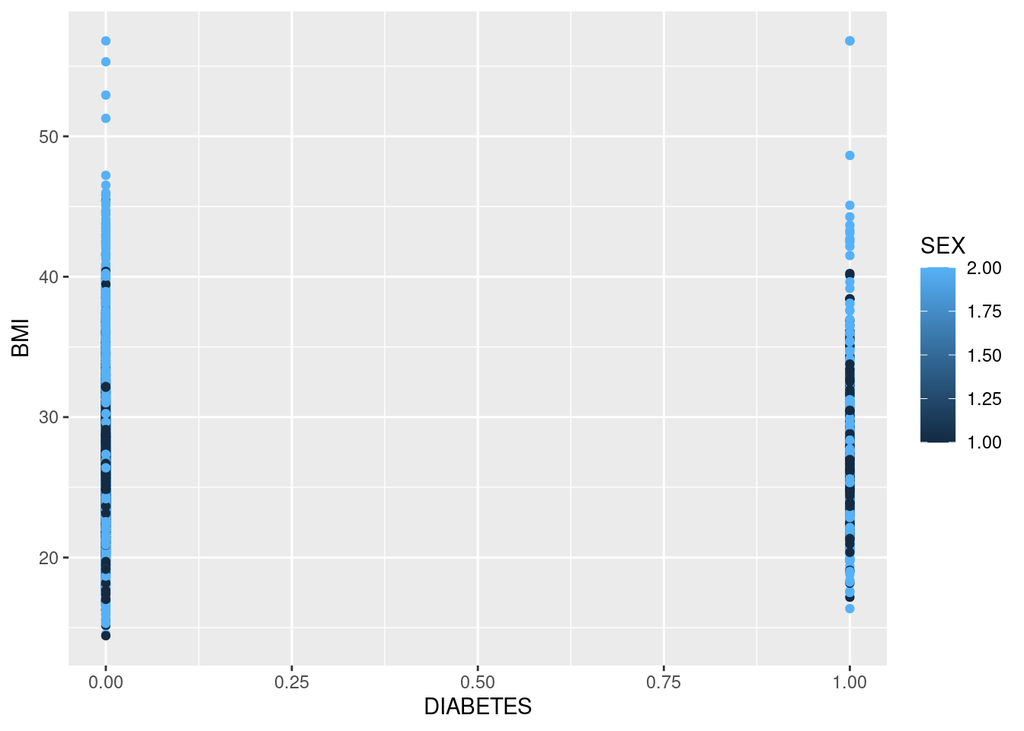

```r
ggplot(data=fhs_data, aes(x=DIABETES, y=BMI))+
  geom_point(aes(colour = SEX))
```

The variance analysis between BMI and Diabetes is:

```r
summary(aov(BMI ~ as.factor(DIABETES), data = filter(fhs_data, PERIOD == 1)))
```

```
##                       Df Sum Sq Mean Sq F value   Pr(>F)
## as.factor(DIABETES)    1    572   572.3   34.27 5.15e-09 ***
## Residuals           4413  73693    16.7
## ---
## Signif. codes:  0 '***' 0.001 '**' 0.01 '*' 0.05 '.' 0.1 ' ' 1
## 19 observations deleted due to missingness
```

### Age versus chronic diseases

An important analysis that also need to be made is check the relationships between age and chronic diseases. The following plots presents these relationships.

#### AGE and DIABETES

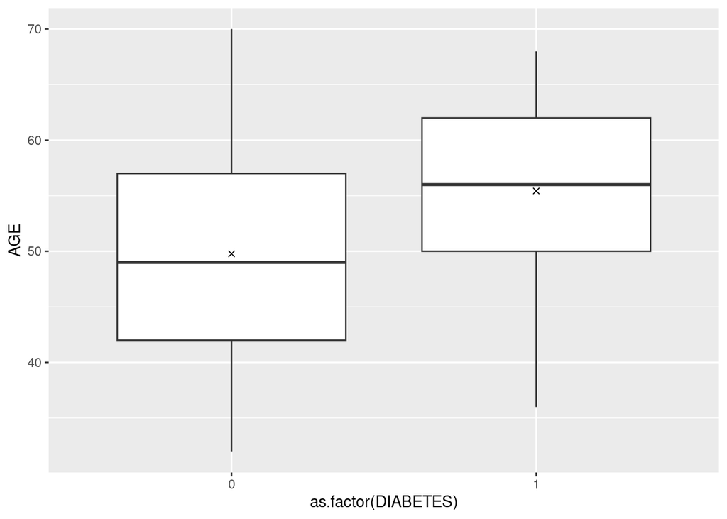

```r
ggplot(filter(fhs_data, PERIOD == 1), aes(x = as.factor(DIABETES), y = AGE)) +
  geom_boxplot() +
  stat_summary(fun.y = "mean", geom = "point", shape = 4)
```

#### AGE and CVD

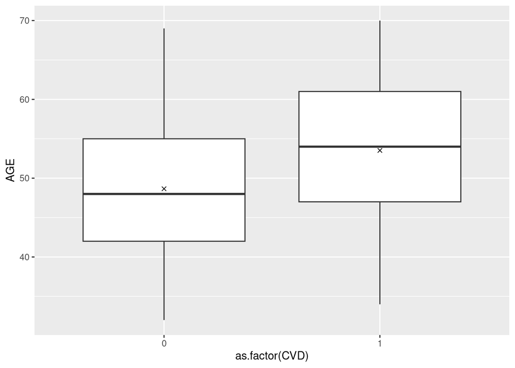

```r
ggplot(filter(fhs_data, PERIOD == 1), aes(x = as.factor(CVD), y = AGE)) +
  geom_boxplot() +
  stat_summary(fun.y = "mean", geom = "point", shape = 4)
```

#### AGE and STROKE

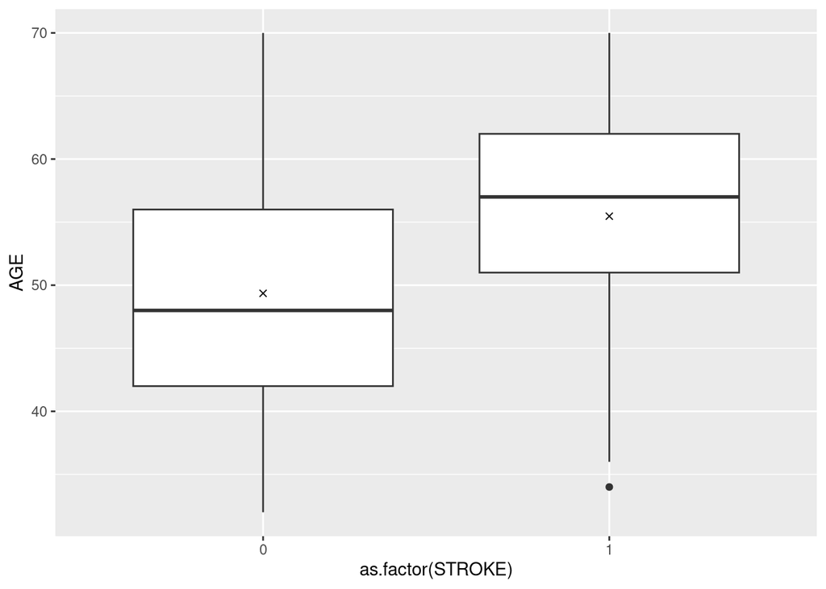

```r
ggplot(filter(fhs_data, PERIOD == 1), aes(x = as.factor(STROKE), y = AGE)) +
  geom_boxplot() +
  stat_summary(fun.y = "mean", geom = "point", shape = 4)
```

#### AGE and HYPERTEN

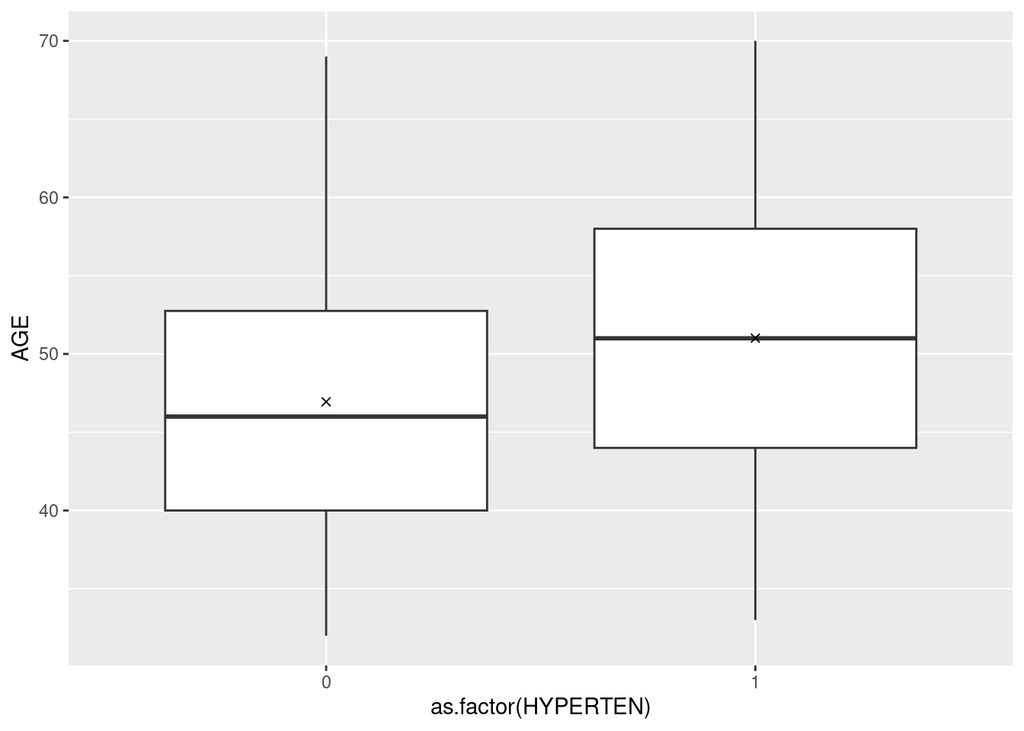

```r
ggplot(filter(fhs_data, PERIOD == 1), aes(x = as.factor(HYPERTEN), y = AGE)) +
  geom_boxplot() +
  stat_summary(fun.y = "mean", geom = "point", shape = 4)
```

## Share

### 1. Participants Health

#### Hypothesis:

- Persons with higher BMI has more chance to develop a heart condition
- A balanced BMI improve the health condition of a person thus avoid the development of an disease heart condition.
- The lower BMI also is related with a lower prevalence of Stroke.

### Consolidated plots

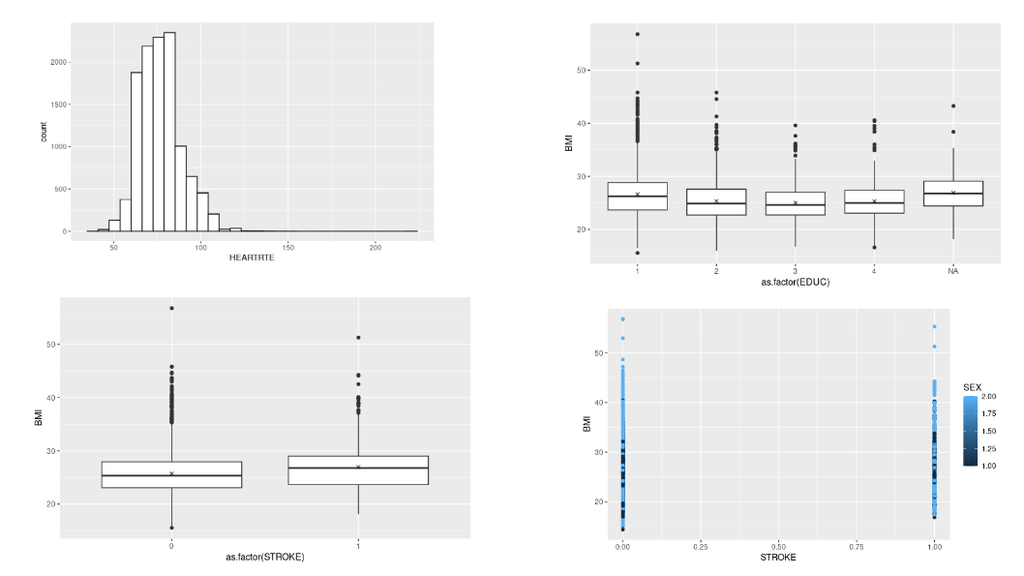

Slide 1!

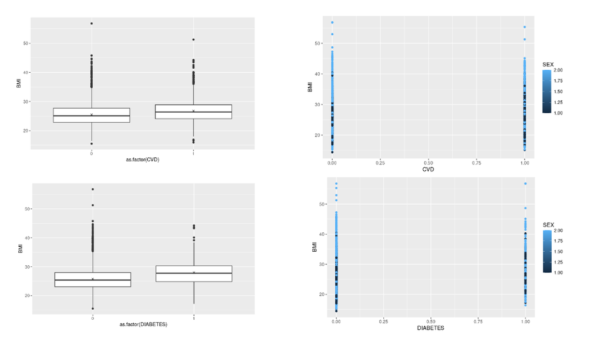

Slide 2!

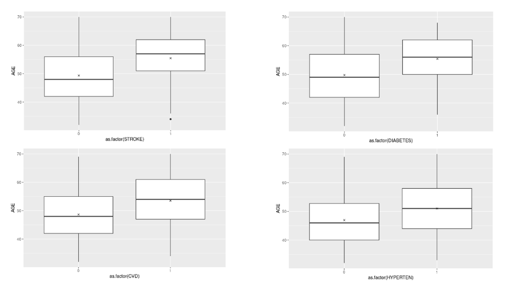

Slide 3!

#### Conclusion:

Age also is related with a higher risk of development chronic diseases.

#### Analysis next steps

- Conduct a machine learning analysis to predict the occurrence of the diseases.

## Act

### Recommendations to improve the population Heart health condition.

By analyzing the Framingham Heart Study dataset we can conclude the following main points:

- Individuals must lower their BMI in order to prevent heart diseases.
- The chronic diseases burden of CVD, stroke and diabetes will decrease if public programs of health care focus on the balance of population BMI.
- Older persons have a tendency to develop heart diseases, diabetes and stroke thus they demands an even more controlled BMI

# Reference:

- [Framingham Heart Study](https://www.framinghamheartstudy.org/)